# Metadatos

José Samos Jiménez (jsamos@ugr.es) Dpto. LSI Universidad de Granada

Citar y Licencia: https://doi.org/10.6084/m9.figshare.27275274.v1 Vídeo: https://youtu.be/0JhPRjEFGHk

# Metadatos

- *Datos para describir y documentar los datos*
- Facilitar la búsqueda y descubrimiento de datos
- Facilitar el acceso y uso
- Facilitar la interoperabilidad
- Documentar la calidad de los datos
- Documentar las transformaciones realizadas

# Naturaleza de los datos

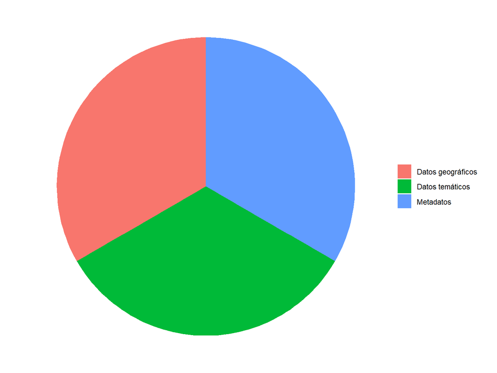

# Ejemplo de contenido

- **Título**: Zonas Forestales Protegidas de la Comunidad Autónoma de Andalucía.
- **Resumen**: Este conjunto de datos contiene la delimitación geográfica de las zonas forestales protegidas en Andalucía.
- **Palabras clave**: Zonas protegidas, bosques, conservación, Andalucía.
- **Categoría temática**: Medio ambiente.
- **Sistema de referencia espacial**: EPSG:25830 (ETRS89 / UTM zona 30N).
- **Extensión geográfica**: Bounding box con coordenadas:
  - Oeste: -6.0000, Este: -1.5000, Sur: 36.0000, Norte: 38.5000
- **Fecha de publicación**: 2022-05-10.
- **Fecha de última actualización**: 2023-04-01.
- **Exactitud posicional**: Precisión de 5 metros.
- **Contacto**: Consejería de Medio Ambiente de Andalucía, contacto: info@medioambiente-andalucia.es.
- **Condiciones de acceso**: Acceso libre bajo licencia CC-BY 4.0.
- **Formato de datos**: Shapefile.
- **Propósito**: Monitoreo y planificación de conservación de áreas naturales.

# Estándares

| Estándar | Organización | Descripción |
| --- | --- | --- |
| *Dublin Core* | DCMI | Elementos para describir recursos digitales |
| *DCAT* | W3C | Vocabulario para describir catálogos de datos en la Web |
| *ISO 19115* | ISO | Estructura para describir datos geográficos |
| *FGDC CSDGM* | FGDC | Estándar de metadatos geográficos en EE.UU. |
| *INSPIRE Metadata Rules* | INSPIRE | Especificaciones para metadatos geográficos en Europa |

# Herramientas

- Creación y edición de metadatos
  - [*CatMDEdit*](https://catmdedit.sourceforge.io/)
  - [*GeoNetwork*](https://geonetwork-opensource.org/)
  - [*ArcGIS Pro*](https://pro.arcgis.com/es/pro-app/latest/help/metadata/create-inspire-metadata.htm)
- Validación de metadatos
  - [*INSPIRE Reference Validator*](https://inspire.ec.europa.eu/validator/)
- Gestión de catálogos de metadatos - basados en CSW
  - [*GeoNetwork*](https://geonetwork-opensource.org/)
  - [*Esri Geoportal Server*](https://www.esri.com/es-es/arcgis/products/esri-geoportal-server/)

# Ejemplos

- [Ejemplo de metadatos](https://idechg.chguadalquivir.es/nodo/Catalogo/GetMetadata.do?uuid=ESCHGPERIMETROS_ABASTECIMIENTO201008190085)
- [Ejemplo de catálogo de metadatos 1](https://idejaen.dipujaen.es/catalogo/srv/es/main.home)
- [Ejemplo de catálogo de metadatos 2](https://ide.caceres.es/geonetwork/srv/spa/catalog.search#/home)
- [Ejemplo de catálogo de IDE](https://idechg.chguadalquivir.es/nodo/Catalogo/index.html#elementos)